# Исследование объявлений о продаже квартир

В вашем распоряжении данные сервиса Яндекс.Недвижимость — архив объявлений о продаже квартир в Санкт-Петербурге и соседних населённых пунктов за несколько лет. Нужно научиться определять рыночную стоимость объектов недвижимости. Ваша задача — установить параметры. Это позволит построить автоматизированную систему: она отследит аномалии и мошенническую деятельность.

По каждой квартире на продажу доступны два вида данных. Первые вписаны пользователем, вторые — получены автоматически на основе картографических данных. Например, расстояние до центра, аэропорта, ближайшего парка и водоёма.

### Откройте файл с данными и изучите общую информацию.

```python
import pandas as pd
df = pd.read_csv('/datasets/real_estate_data.csv', sep = '\t')
```

```python
#прочтем 10 случайных строк, чтобы посмотреть, что все нормально загрузилось
df.sample(10)
```

|  | total_images | last_price | total_area | first_day_exposition | rooms | ceiling_height | floors_total | living_area | floor | is_apartment | ... | kitchen_area | balcony | locality_name | airports_nearest | cityCenters_nearest | parks_around3000 | parks_nearest | ponds_around3000 | ponds_nearest | days_exposition |
| --- | --- | --- | --- | --- | --- | --- | --- | --- | --- | --- | --- | --- | --- | --- | --- | --- | --- | --- | --- | --- | --- |
| 12768 | 5 | 6590000.0 | 82.0 | 2018-11-23T00:00:00 | 3 | 2.65 | 14.0 | 54.2 | 14 | NaN | ... | 11.0 | 1.0 | Санкт-Петербург | 17423.0 | 16219.0 | 1.0 | 368.0 | 2.0 | 218.0 | NaN |
| 19116 | 9 | 980000.0 | 36.0 | 2017-04-27T00:00:00 | 1 | NaN | 5.0 | 18.0 | 1 | NaN | ... | 8.0 | 0.0 | Каменногорск | NaN | NaN | NaN | NaN | NaN | NaN | 154.0 |
| 15165 | 15 | 26259820.0 | 158.0 | 2017-11-30T00:00:00 | 3 | NaN | 16.0 | NaN | 4 | NaN | ... | NaN | NaN | Санкт-Петербург | 31244.0 | 6572.0 | 1.0 | 677.0 | 1.0 | 474.0 | NaN |
| 17688 | 6 | 4550000.0 | 55.0 | 2017-10-13T00:00:00 | 3 | 2.50 | 5.0 | 41.0 | 5 | NaN | ... | 6.0 | NaN | Санкт-Петербург | 28344.0 | 7283.0 | 0.0 | NaN | 0.0 | NaN | 97.0 |
| 10186 | 4 | 5500000.0 | 56.0 | 2017-09-13T00:00:00 | 2 | 3.00 | 5.0 | 35.0 | 2 | NaN | ... | 8.0 | 1.0 | Санкт-Петербург | 19543.0 | 14605.0 | 3.0 | 224.0 | 2.0 | 485.0 | 236.0 |
| 6246 | 6 | 3300000.0 | 44.4 | 2019-03-25T00:00:00 | 2 | 25.00 | 5.0 | 31.3 | 5 | NaN | ... | 5.7 | NaN | Кронштадт | 68923.0 | 50649.0 | 1.0 | 417.0 | 2.0 | 73.0 | NaN |
| 502 | 0 | 11250000.0 | 71.0 | 2017-01-26T00:00:00 | 2 | NaN | 3.0 | 43.0 | 3 | NaN | ... | 8.0 | 0.0 | Санкт-Петербург | 21566.0 | 1217.0 | 0.0 | NaN | 3.0 | 228.0 | 35.0 |
| 21765 | 7 | 1450000.0 | 33.7 | 2017-10-03T00:00:00 | 1 | NaN | 4.0 | 21.0 | 4 | NaN | ... | 6.0 | 1.0 | Любань | NaN | NaN | NaN | NaN | NaN | NaN | 45.0 |
| 111 | 4 | 4590000.0 | 40.0 | 2017-05-29T00:00:00 | 1 | NaN | 6.0 | 18.0 | 1 | NaN | ... | 10.0 | 0.0 | Санкт-Петербург | 20062.0 | 6175.0 | 1.0 | 241.0 | 0.0 | NaN | 31.0 |
| 20612 | 5 | 3650000.0 | 32.5 | 2018-01-18T00:00:00 | 1 | NaN | 20.0 | NaN | 16 | NaN | ... | NaN | NaN | Санкт-Петербург | 15990.0 | 13853.0 | 0.0 | NaN | 1.0 | 584.0 | 45.0 |

10 rows × 22 columns

```python
#посмотрим информацию о датафрейме
df.describe(include = 'all')
```

|  | total_images | last_price | total_area | first_day_exposition | rooms | ceiling_height | floors_total | living_area | floor | is_apartment | ... | kitchen_area | balcony | locality_name | airports_nearest | cityCenters_nearest | parks_around3000 | parks_nearest | ponds_around3000 | ponds_nearest | days_exposition |
| --- | --- | --- | --- | --- | --- | --- | --- | --- | --- | --- | --- | --- | --- | --- | --- | --- | --- | --- | --- | --- | --- |
| count | 23699.000000 | 2.369900e+04 | 23699.000000 | 23699 | 23699.000000 | 14504.000000 | 23613.000000 | 21796.000000 | 23699.000000 | 2775 | ... | 21421.000000 | 12180.000000 | 23650 | 18157.000000 | 18180.000000 | 18181.000000 | 8079.000000 | 18181.000000 | 9110.000000 | 20518.000000 |
| unique | NaN | NaN | NaN | 1491 | NaN | NaN | NaN | NaN | NaN | 2 | ... | NaN | NaN | 364 | NaN | NaN | NaN | NaN | NaN | NaN | NaN |
| top | NaN | NaN | NaN | 2018-02-01T00:00:00 | NaN | NaN | NaN | NaN | NaN | False | ... | NaN | NaN | Санкт-Петербург | NaN | NaN | NaN | NaN | NaN | NaN | NaN |
| freq | NaN | NaN | NaN | 368 | NaN | NaN | NaN | NaN | NaN | 2725 | ... | NaN | NaN | 15721 | NaN | NaN | NaN | NaN | NaN | NaN | NaN |
| mean | 9.858475 | 6.541549e+06 | 60.348651 | NaN | 2.070636 | 2.771499 | 10.673824 | 34.457852 | 5.892358 | NaN | ... | 10.569807 | 1.150082 | NaN | 28793.672193 | 14191.277833 | 0.611408 | 490.804555 | 0.770255 | 517.980900 | 180.888634 |
| std | 5.682529 | 1.088701e+07 | 35.654083 | NaN | 1.078405 | 1.261056 | 6.597173 | 22.030445 | 4.885249 | NaN | ... | 5.905438 | 1.071300 | NaN | 12630.880622 | 8608.386210 | 0.802074 | 342.317995 | 0.938346 | 277.720643 | 219.727988 |
| min | 0.000000 | 1.219000e+04 | 12.000000 | NaN | 0.000000 | 1.000000 | 1.000000 | 2.000000 | 1.000000 | NaN | ... | 1.300000 | 0.000000 | NaN | 0.000000 | 181.000000 | 0.000000 | 1.000000 | 0.000000 | 13.000000 | 1.000000 |
| 25% | 6.000000 | 3.400000e+06 | 40.000000 | NaN | 1.000000 | 2.520000 | 5.000000 | 18.600000 | 2.000000 | NaN | ... | 7.000000 | 0.000000 | NaN | 18585.000000 | 9238.000000 | 0.000000 | 288.000000 | 0.000000 | 294.000000 | 45.000000 |
| 50% | 9.000000 | 4.650000e+06 | 52.000000 | NaN | 2.000000 | 2.650000 | 9.000000 | 30.000000 | 4.000000 | NaN | ... | 9.100000 | 1.000000 | NaN | 26726.000000 | 13098.500000 | 0.000000 | 455.000000 | 1.000000 | 502.000000 | 95.000000 |
| 75% | 14.000000 | 6.800000e+06 | 69.900000 | NaN | 3.000000 | 2.800000 | 16.000000 | 42.300000 | 8.000000 | NaN | ... | 12.000000 | 2.000000 | NaN | 37273.000000 | 16293.000000 | 1.000000 | 612.000000 | 1.000000 | 729.000000 | 232.000000 |
| max | 50.000000 | 7.630000e+08 | 900.000000 | NaN | 19.000000 | 100.000000 | 60.000000 | 409.700000 | 33.000000 | NaN | ... | 112.000000 | 5.000000 | NaN | 84869.000000 | 65968.000000 | 3.000000 | 3190.000000 | 3.000000 | 1344.000000 | 1580.000000 |

11 rows × 22 columns

```python
#посмотрим типы данных и то, насколько они заполнены
df.info()
```

```
<class 'pandas.core.frame.DataFrame'>
RangeIndex: 23699 entries, 0 to 23698
Data columns (total 22 columns):
 #   Column                Non-Null Count  Dtype
---  ------                --------------  -----
 0   total_images          23699 non-null  int64
 1   last_price            23699 non-null  float64
 2   total_area            23699 non-null  float64
 3   first_day_exposition  23699 non-null  object
 4   rooms                 23699 non-null  int64
 5   ceiling_height        14504 non-null  float64
 6   floors_total          23613 non-null  float64
 7   living_area           21796 non-null  float64
 8   floor                 23699 non-null  int64
 9   is_apartment          2775 non-null   object
 10  studio                23699 non-null  bool
 11  open_plan             23699 non-null  bool
 12  kitchen_area          21421 non-null  float64
 13  balcony               12180 non-null  float64
 14  locality_name         23650 non-null  object
 15  airports_nearest      18157 non-null  float64
 16  cityCenters_nearest   18180 non-null  float64
 17  parks_around3000      18181 non-null  float64
 18  parks_nearest         8079 non-null   float64
 19  ponds_around3000      18181 non-null  float64
 20  ponds_nearest         9110 non-null   float64
 21  days_exposition       20518 non-null  float64
dtypes: bool(2), float64(14), int64(3), object(3)
memory usage: 3.7+ MB
```

```
array([[<AxesSubplot:title={'center':'total_images'}>,
        <AxesSubplot:title={'center':'last_price'}>,
        <AxesSubplot:title={'center':'total_area'}>,
        <AxesSubplot:title={'center':'rooms'}>],
       [<AxesSubplot:title={'center':'ceiling_height'}>,
        <AxesSubplot:title={'center':'floors_total'}>,
        <AxesSubplot:title={'center':'living_area'}>,
        <AxesSubplot:title={'center':'floor'}>],
       [<AxesSubplot:title={'center':'kitchen_area'}>,
        <AxesSubplot:title={'center':'balcony'}>,
        <AxesSubplot:title={'center':'airports_nearest'}>,
        <AxesSubplot:title={'center':'cityCenters_nearest'}>],
       [<AxesSubplot:title={'center':'parks_around3000'}>,
        <AxesSubplot:title={'center':'parks_nearest'}>,
        <AxesSubplot:title={'center':'ponds_around3000'}>,
        <AxesSubplot:title={'center':'ponds_nearest'}>],
       [<AxesSubplot:title={'center':'days_exposition'}>, <AxesSubplot:>,
        <AxesSubplot:>, <AxesSubplot:>]], dtype=object)
```

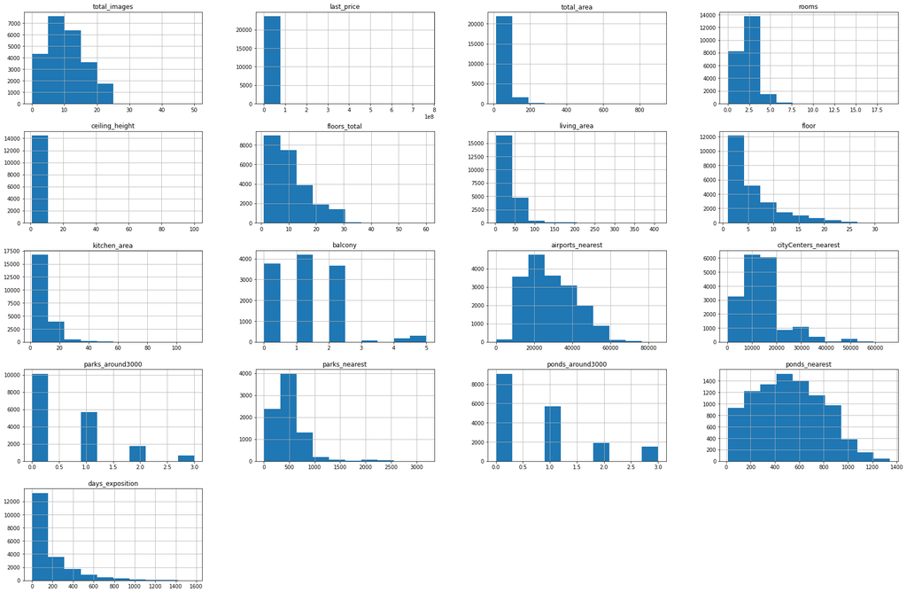

```python
# сформируем гистограммы по столбцам
df.hist(figsize=(30, 20))
```

Выводы:

1. В данных есть пропуски. Много пропусков.
2. Диаграммы показывают, что, в первом приближении, по тем данным, кторые должны иметь целочисленное представление (количество комнат, например) ошибок ввода не заметно, по тем данным, которые могут иметь представление с плавающей точкой (расстояние до объектов, например), соблюдается нормальное распределение. Но, в любом случае, необходим более детальный анализ выбросов.
3. Данные в некоторых столбцах, например, first_day_exposition и is_appartment требуют замены типа

### Предобработка данных

#### Уникальные значения

В связи с тем, что мы анализируем квартиры по месторасположению, считаю необходимым проанализировать дубликаты и неявные дубликаты по столбцу locality_name. Если данные этого столбца не заполнены, то такая строка не информативна в принципе, вне зависимости от заполненности остальных строк.

```python
# Сформируем список уникальных наименований и посчитаем их количество
display(df['locality_name'].unique().tolist())
print('количество', len(df['locality_name'].unique().tolist()))
```

```
['Санкт-Петербург',
 'посёлок Шушары',
 'городской посёлок Янино-1',
 'посёлок Парголово',
 'посёлок Мурино',
 'Ломоносов',
 'Сертолово',
 'Петергоф',
 'Пушкин',
 'деревня Кудрово',
 'Коммунар',
 'Колпино',
 'поселок городского типа Красный Бор',
 'Гатчина',
 'поселок Мурино',
 'деревня Фёдоровское',
 'Выборг',
 'Кронштадт',
 'Кировск',
 'деревня Новое Девяткино',
 'посёлок Металлострой',
 'посёлок городского типа Лебяжье',
 'посёлок городского типа Сиверский',
 'поселок Молодцово',
 'поселок городского типа Кузьмоловский',
 'садовое товарищество Новая Ропша',
 'Павловск',
 'деревня Пикколово',
 'Всеволожск',
 'Волхов',
 'Кингисепп',
 'Приозерск',
 'Сестрорецк',
 'деревня Куттузи',
 'посёлок Аннино',
 'поселок городского типа Ефимовский',
 'посёлок Плодовое',
 'деревня Заклинье',
 'поселок Торковичи',
 'поселок Первомайское',
```

[output cut: 310 more lines]

```
 'деревня Пустынка',
 'поселок Рабитицы',
 'деревня Большой Сабск',
 'деревня Русско',
 'деревня Лупполово',
 'деревня Большое Рейзино',
 'деревня Малая Романовка',
 'поселок Дружноселье',
 'поселок Пчевжа',
 'поселок Володарское',
 'деревня Нижняя',
 'коттеджный посёлок Лесное',
 'деревня Тихковицы',
 'деревня Борисова Грива',
 'посёлок Дзержинского']
```

```
количество 365
```

Можно выделить 2 проблемы:

1. Буква "Ё" в словах "поселок" и "посёлок". Заменим все на букву "е"
2. По-разному закодированы локации. Например: "Мурино", "посёлок Мурино" и "поселок Мурино". Надо привести в соответствие. Предлагается убрать название поселков

```python
#избавимся от букы "ё"
df['locality_name'] = df['locality_name'].str.replace('ё', 'е', regex=True)
print('количество', len(df['locality_name'].unique().tolist()))
# убрали 34 дублирования
```

```
количество 331
```

```python
#посмотрим, какие типы населенных пунктов есть
display(sorted(df['locality_name'].astype(str).unique().tolist()))
```

```
['nan',
 'Бокситогорск',
 'Волосово',
 'Волхов',
 'Всеволожск',
 'Выборг',
 'Высоцк',
 'Гатчина',
 'Зеленогорск',
 'Ивангород',
 'Каменногорск',
 'Кингисепп',
 'Кириши',
 'Кировск',
 'Колпино',
 'Коммунар',
 'Красное Село',
 'Кронштадт',
 'Кудрово',
 'Лодейное Поле',
 'Ломоносов',
 'Луга',
 'Любань',
 'Мурино',
 'Никольское',
 'Новая Ладога',
 'Отрадное',
 'Павловск',
 'Петергоф',
 'Пикалево',
 'Подпорожье',
 'Приморск',
 'Приозерск',
 'Пушкин',
 'Санкт-Петербург',
 'Светогорск',
 'Сертолово',
 'Сестрорецк',
 'Сланцы',
 'Сосновый Бор',
```

[output cut: 276 more lines]

```
 'поселок станции Свирь',
 'садоводческое некоммерческое товарищество Лесная Поляна',
 'садовое товарищество Новая Ропша',
 'садовое товарищество Приладожский',
 'садовое товарищество Рахья',
 'садовое товарищество Садко',
 'село Копорье',
 'село Никольское',
 'село Павлово',
 'село Паша',
 'село Путилово',
 'село Рождествено',
 'село Русско-Высоцкое',
 'село Старая Ладога',
 'село Шум']
```

```python
# Удалим типы. Начнем с тех, которые состоят из 2 слов
df['locality_name'] = df['locality_name'].str.replace('садовое товарищество ', '', regex=True)
df['locality_name'] = df['locality_name'].str.replace('поселок станции ', '', regex=True)
df['locality_name'] = df['locality_name'].str.replace('поселок при железнодорожной станции ', '', regex=True)
df['locality_name'] = df['locality_name'].str.replace('поселок городского типа ', '', regex=True)
df['locality_name'] = df['locality_name'].str.replace('городской поселок ', '', regex=True)
df['locality_name'] = df['locality_name'].str.replace('коттеджный поселок ', '', regex=True)
df['locality_name'] = df['locality_name'].str.replace('поселок ', '', regex=True)
df['locality_name'] = df['locality_name'].str.replace('деревня ', '', regex=True)
print('количество уникальных элементов', len(df['locality_name'].unique().tolist()))
```

```
количество уникальных элементов 308
```

```python
# а теперь посмотрим количество строк, где адрес не заполнен
df['locality_name'].isna().sum()
```

```
49
```

```python
#удалим их и посмотрим, сколько уникальных элементов осталось
df = df.dropna(subset=['locality_name'])
print('Количество незаполненных адресов после удаления', df['locality_name'].isna().sum())
print('Количество уникальных элементов', len(df['locality_name'].unique().tolist()))
```

```
Количество незаполненных адресов после удаления 0
Количество уникальных элементов 307
```

```python
# Код ревьюера

pd.Series(['посёлок Длинное Название']).str.extract('([А-Я].*)')
```

|  | 0 |
| --- | --- |
| 0 | Длинное Название |